# Człowiek kontra Góry - Analiza

Michał Król

2026-01-20

### Wstęp: Walka o każdy oddech

Himalaizm wysokogórski od dekad fascynuje ludzkość jako ostateczny sprawdzian wytrzymałości, technologii i woli przetrwania. Poniższa analiza, oparta na danych z bazy wspinaczy (m.in. The Himalayan Database), ma na celu zgłębienie statystycznych aspektów wypraw na najwyższe szczyty świata.

W analizie przyjrzymy się nie tylko demografii uczestników, ale przede wszystkim czynnikom, które oddzielają sukces od porażki oraz życie od śmierci w ekstremalnie trudnych warunkach m.in w tzw. “Strefie Śmierci”. Czy dodatkowy tlen to gwarancja bezpieczeństwa? Dlaczego “strefa śmierci” jest tak bezlitosna? I wreszcie – jaką rolę we wspinaniu odgrywają lokalni przewodnicy zwani Sherpami, bez których zdobycie Korony Himalajów byłoby dla wielu niemożliwe?

### Użyte biblioteki

library(mice) library(ggplot2) library(scales)

### Wczytanie i wstępny przegląd danych

Na początku sprawdzam strukturę danych, aby zrozumieć, z jakimi typami zmiennych mam do czynienia.

```r
dane <- read.csv("climbers_sub1.csv", sep = ",")
head(dane, 6)
```

```
##   rownames expedition_id    member_id peak_id  peak_name year season sex age
## 1        1     AMAD81101 AMAD81101-03    AMAD Ama Dablam 1981 Spring   M  28
## 2        2     AMAD81101 AMAD81101-04    AMAD Ama Dablam 1981 Spring   M  27
## 3        3     AMAD81101 AMAD81101-02    AMAD Ama Dablam 1981 Spring   M  35
## 4        4     AMAD81101 AMAD81101-05    AMAD Ama Dablam 1981 Spring   M  37
## 5        5     AMAD81101 AMAD81101-06    AMAD Ama Dablam 1981 Spring   M  43
## 6        6     AMAD81101 AMAD81101-07    AMAD Ama Dablam 1981 Spring   M  38
##   citizenship expedition_role hired highpoint_metres success  solo oxygen_used
## 1       Spain         Climber FALSE             6814    TRUE FALSE       FALSE
## 2       Spain      Exp Doctor FALSE             6814    TRUE FALSE       FALSE
## 3       Spain   Deputy Leader FALSE             6814    TRUE FALSE       FALSE
## 4       Spain         Climber FALSE             6814    TRUE FALSE       FALSE
## 5      France         Climber FALSE             6814    TRUE FALSE       FALSE
## 6       Spain         Climber FALSE               NA   FALSE FALSE       FALSE
##    died death_cause death_height_metres injured injury_type
## 1 FALSE                              NA   FALSE
## 2 FALSE                              NA   FALSE
## 3 FALSE                              NA   FALSE
## 4 FALSE                              NA   FALSE
## 5 FALSE                              NA   FALSE
## 6 FALSE                              NA   FALSE
##   injury_height_metres count height_metres first_ascent_year
## 1                   NA    12          6814              1961
## 2                   NA    12          6814              1961
## 3                   NA    12          6814              1961
## 4                   NA    12          6814              1961
## 5                   NA    12          6814              1961
## 6                   NA    12          6814              1961
```

```r
tail(dane, 6)
```

```
##      rownames expedition_id    member_id peak_id peak_name year season sex age
## 2071     2071     EVER19120 EVER19120-22    EVER   Everest 2019 Spring   M  19
## 2072     2072     EVER19120 EVER19120-23    EVER   Everest 2019 Spring   M  36
## 2073     2073     EVER19120 EVER19120-24    EVER   Everest 2019 Spring   M  31
## 2074     2074     EVER19120 EVER19120-25    EVER   Everest 2019 Spring   M  19
## 2075     2075     EVER19120 EVER19120-26    EVER   Everest 2019 Spring   M  35
## 2076     2076     EVER19120 EVER19120-27    EVER   Everest 2019 Spring   M  22
##      citizenship expedition_role hired highpoint_metres success  solo
## 2071       Nepal      H-A Worker  TRUE             8850    TRUE FALSE
## 2072       Nepal      H-A Worker  TRUE             8850    TRUE FALSE
## 2073       Nepal      H-A Worker  TRUE             8850    TRUE FALSE
## 2074       Nepal      H-A Worker  TRUE             8850    TRUE FALSE
## 2075       Nepal      H-A Worker  TRUE             8850    TRUE FALSE
## 2076       Nepal      H-A Worker  TRUE             8850    TRUE FALSE
##      oxygen_used  died death_cause death_height_metres injured injury_type
## 2071        TRUE FALSE                              NA   FALSE
## 2072        TRUE FALSE                              NA   FALSE
## 2073        TRUE FALSE                              NA   FALSE
## 2074        TRUE FALSE                              NA   FALSE
## 2075        TRUE FALSE                              NA   FALSE
## 2076        TRUE FALSE                              NA   FALSE
##      injury_height_metres count height_metres first_ascent_year
## 2071                   NA    27          8850              1953
## 2072                   NA    27          8850              1953
## 2073                   NA    27          8850              1953
## 2074                   NA    27          8850              1953
## 2075                   NA    27          8850              1953
## 2076                   NA    27          8850              1953
```

```r
dim(dane)
```

```
## [1] 2076   25
```

```r
summary(dane)
```

```
##    rownames         expedition_id       member_id           peak_id
##  Length:2076        Length:2076        Length:2076        Length:2076
##  Class :character   Class :character   Class :character   Class :character
##  Mode  :character   Mode  :character   Mode  :character   Mode  :character
##
##
##
##
##   peak_name              year         season              sex
##  Length:2076        Min.   :1978   Length:2076        Length:2076
##  Class :character   1st Qu.:1996   Class :character   Class :character
##  Mode  :character   Median :2006   Mode  :character   Mode  :character
##                     Mean   :2003
##                     3rd Qu.:2011
##                     Max.   :2019
##                     NA's   :1
##       age        citizenship        expedition_role      hired
##  Min.   :17.00   Length:2076        Length:2076        Mode :logical
##  1st Qu.:29.00   Class :character   Class :character   FALSE:1590
##  Median :36.00   Mode  :character   Mode  :character   TRUE :485
##  Mean   :36.95                                         NA's :1
##  3rd Qu.:43.00
##  Max.   :76.00
##  NA's   :1
##  highpoint_metres  success           solo         oxygen_used
##  Min.   :4900     Mode :logical   Mode :logical   Mode :logical
##  1st Qu.:6750     FALSE:1268      FALSE:2073      FALSE:1474
##  Median :7400     TRUE :807       TRUE :2         TRUE :601
##  Mean   :7555     NA's :1         NA's :1         NA's :1
##  3rd Qu.:8850
##  Max.   :8850
##  NA's   :593
##     died         death_cause        death_height_metres  injured
##  Mode :logical   Length:2076        Min.   :3400        Mode :logical
##  FALSE:2056      Class :character   1st Qu.:6150        FALSE:2051
##  TRUE :19        Mode  :character   Median :6600        TRUE :24
##  NA's :1                            Mean   :6771        NA's :1
##                                     3rd Qu.:7800
##                                     Max.   :8650
##                                     NA's   :2057
##  injury_type        injury_height_metres     count       height_metres
##  Length:2076        Min.   :3960         Min.   : 5.00   Min.   :5929
##  Class :character   1st Qu.:5575         1st Qu.: 8.00   1st Qu.:7138
##  Mode  :character   Median :6325         Median :11.00   Median :8167
##                     Mean   :6406         Mean   :13.89   Mean   :7990
##                     3rd Qu.:6950         3rd Qu.:18.00   3rd Qu.:8850
##                     Max.   :8400         Max.   :44.00   Max.   :8850
##                     NA's   :2062         NA's   :1       NA's   :1
##  first_ascent_year
##  Min.   :1936
##  1st Qu.:1953
##  Median :1954
##  Mean   :1959
##  3rd Qu.:1961
##  Max.   :2017
##  NA's   :8
```

```r
str(dane)
```

```
## 'data.frame':    2076 obs. of  25 variables:
##  $ rownames            : chr  "1" "2" "3" "4" ...
##  $ expedition_id       : chr  "AMAD81101" "AMAD81101" "AMAD81101" "AMAD81101" ...
##  $ member_id           : chr  "AMAD81101-03" "AMAD81101-04" "AMAD81101-02" "AMAD81101-05" ...
##  $ peak_id             : chr  "AMAD" "AMAD" "AMAD" "AMAD" ...
##  $ peak_name           : chr  "Ama Dablam" "Ama Dablam" "Ama Dablam" "Ama Dablam" ...
##  $ year                : int  1981 1981 1981 1981 1981 1981 1981 1981 1981 1981 ...
##  $ season              : chr  "Spring" "Spring" "Spring" "Spring" ...
##  $ sex                 : chr  "M" "M" "M" "M" ...
##  $ age                 : int  28 27 35 37 43 38 23 36 48 25 ...
##  $ citizenship         : chr  "Spain" "Spain" "Spain" "Spain" ...
##  $ expedition_role     : chr  "Climber" "Exp Doctor" "Deputy Leader" "Climber" ...
##  $ hired               : logi  FALSE FALSE FALSE FALSE FALSE FALSE ...
##  $ highpoint_metres    : int  6814 6814 6814 6814 6814 NA 6814 NA 6814 6814 ...
##  $ success             : logi  TRUE TRUE TRUE TRUE TRUE FALSE ...
##  $ solo                : logi  FALSE FALSE FALSE FALSE FALSE FALSE ...
##  $ oxygen_used         : logi  FALSE FALSE FALSE FALSE FALSE FALSE ...
##  $ died                : logi  FALSE FALSE FALSE FALSE FALSE FALSE ...
##  $ death_cause         : chr  "" "" "" "" ...
##  $ death_height_metres : int  NA NA NA NA NA NA NA NA NA NA ...
##  $ injured             : logi  FALSE FALSE FALSE FALSE FALSE FALSE ...
##  $ injury_type         : chr  "" "" "" "" ...
##  $ injury_height_metres: int  NA NA NA NA NA NA NA NA NA NA ...
##  $ count               : int  12 12 12 12 12 12 12 12 12 12 ...
##  $ height_metres       : int  6814 6814 6814 6814 6814 6814 6814 6814 6814 6814 ...
##  $ first_ascent_year   : int  1961 1961 1961 1961 1961 1961 1961 1961 1961 1961 ...
```

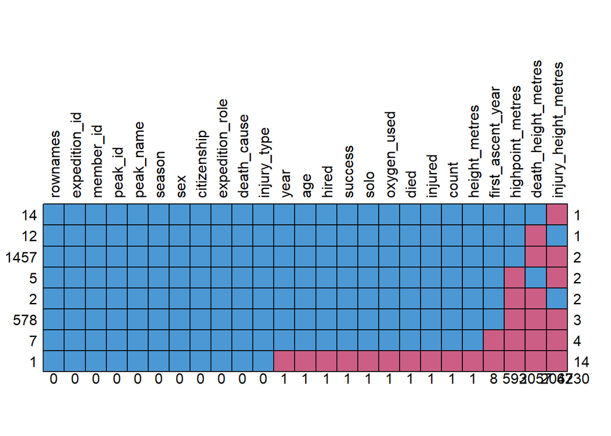

```
##      rownames expedition_id member_id peak_id peak_name season sex citizenship
## 14          1             1         1       1         1      1   1           1
## 12          1             1         1       1         1      1   1           1
## 1457        1             1         1       1         1      1   1           1
## 5           1             1         1       1         1      1   1           1
## 2           1             1         1       1         1      1   1           1
## 578         1             1         1       1         1      1   1           1
## 7           1             1         1       1         1      1   1           1
## 1           1             1         1       1         1      1   1           1
##             0             0         0       0         0      0   0           0
##      expedition_role death_cause injury_type year age hired success solo
## 14                 1           1           1    1   1     1       1    1
## 12                 1           1           1    1   1     1       1    1
## 1457               1           1           1    1   1     1       1    1
## 5                  1           1           1    1   1     1       1    1
```

[output cut: 25 more lines]

```r
md.pattern(dane, rotate.names = TRUE)
```

```r
View(dane)


table(dane$citizenship)
```

```
##
##                         Argentina        Australia          Austria
##                1                3               40               43
##       Bangladesh          Belgium         Bulgaria           Canada
##                2                4               16               30
## Canada/Macedonia            Chile            China   Czech Republic
##                1                4               88               14
##   Czechoslovakia          Denmark          Ecuador         Egypt/UK
##                1                3                6                1
##          Estonia          Finland           France       France/USA
##                2                8              151                1
##          Germany           Greece        Guatemala            India
##               47               12                1               46
##             Iran          Ireland           Israel            Italy
##               12                8                1               81
##            Japan       Kazakhstan    Liechtenstein        Lithuania
##              152                6                1                1
##       Luxembourg         Malaysia        Mauritius           Mexico
##                1                9                1                6
##            Nepal      Netherlands      New Zealand           Norway
##              485               26               34               11
##           Poland    Poland/Canada       Poland/USA         Portugal
##               40                1                1                2
##          Romania           Russia         S Africa          S Korea
##                2               24                5              107
##        Singapore         Slovakia         Slovenia            Spain
##                4                3                1               95
##           Sweden      Switzerland           Taiwan               UK
##                5               49                3              152
##          Ukraine              USA       USA/Russia           USA/UK
##                7              201                1                1
##        Venezuela        W Germany
##                6                6
```

```r
table(dane$expedition_role)
```

```
##
##                                         ABC Manager                BC Manager
##                         2                         1                         9
##        BC Medical Officer                 Cameraman                   Climber
##                         1                         2                      1253
## Climber (trekking agency)            Climber/BC Mgr         Climber/Cameraman
##                         1                         1                         2
##             Climber/Guide        Climber/H-A Worker          Climbing Advisor
##                         1                         2                         1
##            Climbing Guide   Climbing Ldr/Exp Doctor           Climbing Leader
##                         5                         1                        13
##           Climbing sirdar                 Co-Leader             Deputy Leader
##                         1                         6                        38
##                Exp Doctor          Exp Photographer                 Film Team
##                        37                         1                         2
##            General Leader             H-A Assistant                H-A Worker
##                         1                        24                       444
##                Journalist                    Leader       Leader of Jap. Mbrs
##                         2                       195                         1
##                    Member              Photographer                    Porter
##                         8                         1                         1
##            Radio Operator                 Rope Team       Sandrine Marie Rose
##                         1                         3                         1
##                    Sirdar                   Support              Video Editor
##                         9                         3                         1
##         Wireless Operater
##                         1
```

### Przygotowanie danych

Usuwam braki w statusie przeżycia oraz standaryzuje przyczyny śmierci.

Analiza braków danych na wykresie (md.pattern) wykazała:

Najwięcej braków (różowe pola) dotyczy zmiennych warunkowych (jak wysokość śmierci), co potwierdza, że większość uczestników bezpiecznie zakończyła wyprawę.

Dokonana Korekta: Podczas wstępnej analizy zbioru danych natrafiłem na jeden wiersz z brakującą wartością (NA) w kluczowej kolumnie died. Ze względu na brak możliwości jednoznacznego uzupełnienia tej informacji oraz niewielki wpływ na wielkość zbioru (1 wiersz z 2000 wierszów), zdecydowałem się go usunąć, aby nie zaburzał dalszych statystyk dotyczących śmiertelności.

```r
table(dane$died)
```

```
##
## FALSE  TRUE
##  2056    19
```

```r
#przygotowanie danych
table(dane$died, dane$death_cause, useNA = "always")
```

```
##
##               AMS Avalanche Exposure / frostbite Fall Illness (non-AMS) Unknown
##   FALSE 2056    0         0                    0    0                 0       0
##   TRUE     0    6         6                    1    4                 1       1
##   <NA>     1    0         0                    0    0                 0       0
##
##         <NA>
##   FALSE    0
##   TRUE     0
##   <NA>     0
```

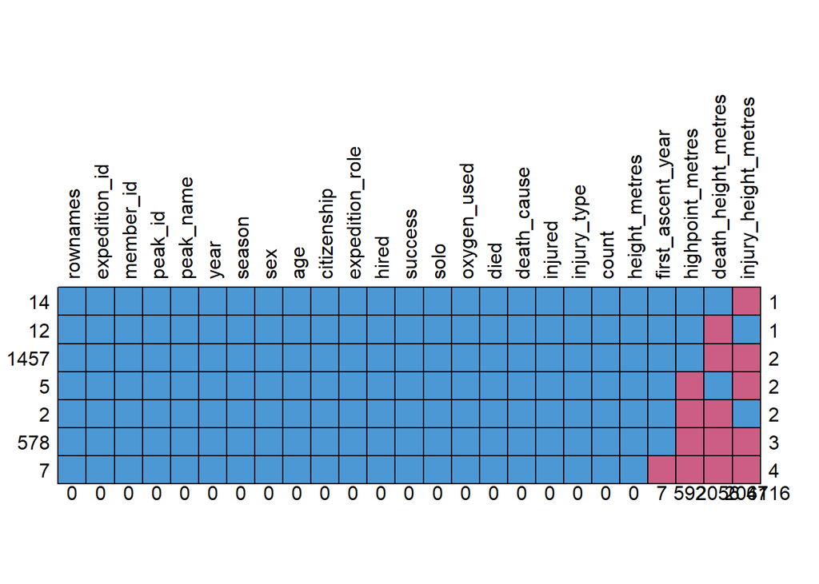

```
##      rownames expedition_id member_id peak_id peak_name year season sex age
## 14          1             1         1       1         1    1      1   1   1
## 12          1             1         1       1         1    1      1   1   1
## 1457        1             1         1       1         1    1      1   1   1
## 5           1             1         1       1         1    1      1   1   1
## 2           1             1         1       1         1    1      1   1   1
## 578         1             1         1       1         1    1      1   1   1
## 7           1             1         1       1         1    1      1   1   1
##             0             0         0       0         0    0      0   0   0
##      citizenship expedition_role hired success solo oxygen_used died
## 14             1               1     1       1    1           1    1
## 12             1               1     1       1    1           1    1
## 1457           1               1     1       1    1           1    1
## 5              1               1     1       1    1           1    1
## 2              1               1     1       1    1           1    1
```

[output cut: 21 more lines]

```r
# Usuwam ten jeden niepewny rekord z NA w statusie 'died'
dane <- dane[!is.na(dane$died), ]
md.pattern(dane, rotate.names = TRUE)
```

```r
# Czyszczenie kolumny death_cause
dane$death_cause <- as.character(dane$death_cause)
dane$death_cause[dane$death_cause == "" | dane$death_cause == "Survied"] <- "Survived"

# Zamiana zmiennych na faktory
dane$sex <- as.factor(dane$sex)
dane$solo <- as.factor(dane$solo)




# Zamiana z nadaniem czytelnych polskich nazw
dane$success <- factor(dane$success, levels = c("FALSE", "TRUE"), labels = c("Porażka", "Sukces"))
dane$oxygen_used <- factor(dane$oxygen_used, levels = c("FALSE", "TRUE"), labels = c("Bez tlenu", "Z tlenem"))
dane$died <- factor(dane$died, levels = c("FALSE", "TRUE"), labels = c("Przeżył", "Zginął"))

# Zamiana z zachowaniem kolejności pór roku
dane$season <- factor(dane$season, levels = c("Spring", "Summer", "Autumn", "Winter"))


# Na koniec zmienna z przyczynami śmierci

dane$hired <- factor(as.character(dane$hired), levels = c("FALSE", "TRUE"), labels = c("Uczestnik", "Sherpa"))


dane$death_cause <- as.factor(dane$death_cause)
levels(dane$sex) <- c("Kobieta", "Mężczyzna")
dane$highpoint_metres <- as.numeric(dane$highpoint_metres)
View(dane)

summary(dane$success)
```

```
## Porażka  Sukces
##    1268     807
```

```r
summary(dane$sex)
```

```
##   Kobieta Mężczyzna
##       193      1882
```

```r
summary(dane$age)
```

```
##    Min. 1st Qu.  Median    Mean 3rd Qu.    Max.
##   17.00   29.00   36.00   36.95   43.00   76.00
```

```r
summary(dane$hired)
```

```
## Uczestnik    Sherpa
##      1590       485
```

### Analiza wartości odstających

Sprawdzamy, czy wiek i osiągane wysokości zawierają błędy lub ekstremalne wartości, które mogłyby zaburzyć średnią.

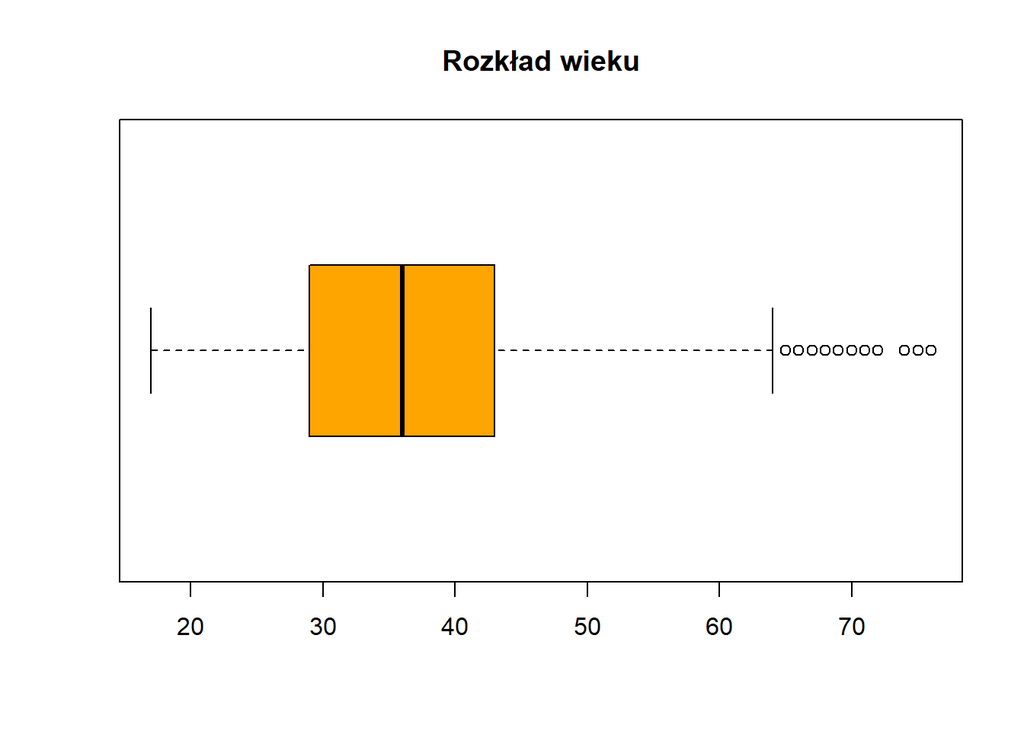

```r
boxplot(dane$age,
        main = "Rozkład wieku",
        col = "orange",
        horizontal = TRUE)
```

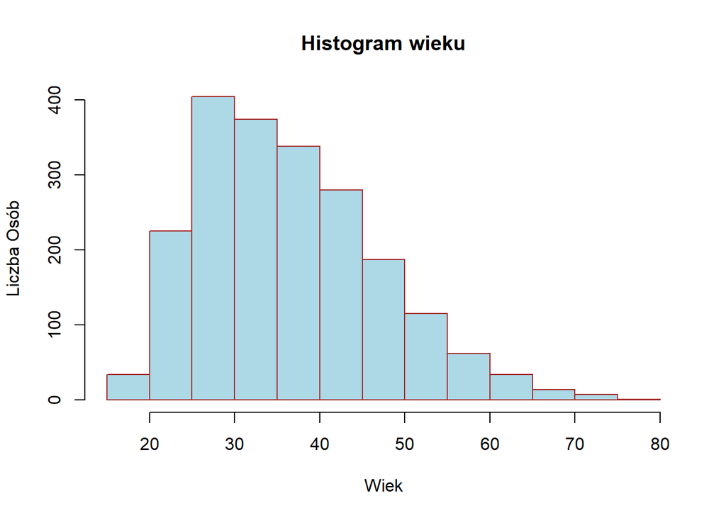

```r
hist(dane$age, breaks = 20, col = "lightblue", border = "brown", main = "Histogram wieku",
     xlab = "Wiek", ylab = "Liczba Osób")
```

### Obserwacje:

Rozkład wieku przypomina rozkład normalny z lekkim prawostronnym wydłużeniem. Mediana oscyluje między 35, a 40 lat. Na prawo od wykresu pudełkowego widać pojedyncze kropki powyżej 70 roku życia to nasi “seniorzy” – w świecie himalaizmu są to wartości ekstremalne, ale historycznie możliwe, dlatego zostają w zbiorze

### Osiągane wysokości

Sprawdźmy, czy najwyższe osiągnięte punkty (highpoint_metres) nie przekraczają wysokości najwyższych szczytów Ziemi.

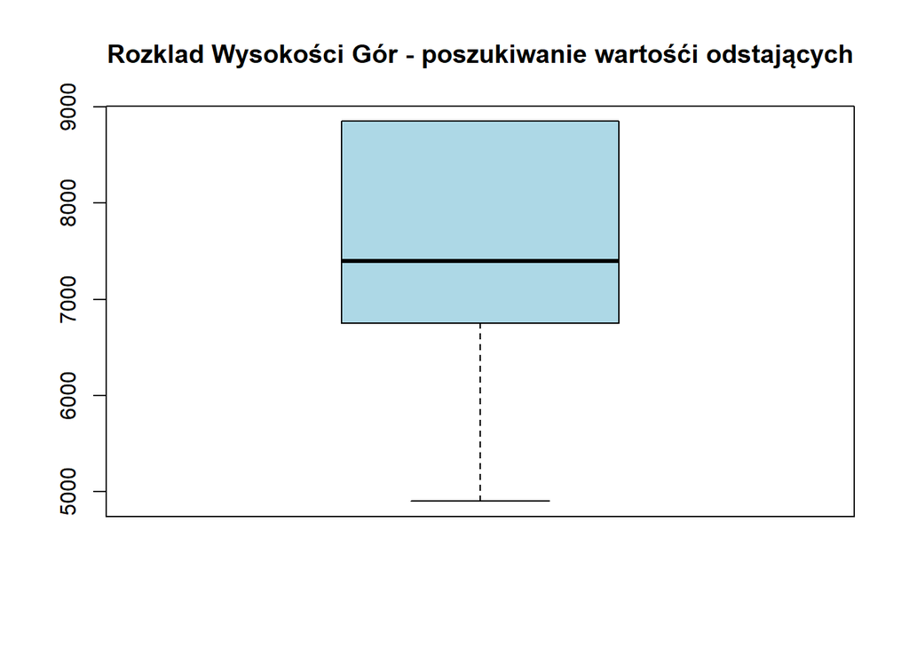

```r
#sprawdzenie wysokości

boxplot(dane$highpoint_metres,
        main = "Rozklad Wysokości Gór - poszukiwanie wartośći odstających",
        col = "lightblue")
```

```r
#brak wartośći odstających
summary(dane[, c("age", "highpoint_metres")])
```

```
##       age        highpoint_metres
##  Min.   :17.00   Min.   :4900
##  1st Qu.:29.00   1st Qu.:6750
##  Median :36.00   Median :7400
##  Mean   :36.95   Mean   :7555
##  3rd Qu.:43.00   3rd Qu.:8850
##  Max.   :76.00   Max.   :8850
##                  NA's   :592
```

### Wniosek:

Statystyki opisowe potwierdzają, że dane mieszczą się w granicach fizjologicznych i geograficznych (maksymalna wysokość nie przekracza szczytu Mount Everest), co pozwala uznać zbiór za wiarygodny

### Rzut okiem na pewne ogólne statystyki - przed głębszą analizą

```r
# Kto jest Najstarsza osoba?

dane[which.max(dane$age), c("age", "sex", "citizenship", "success")]
```

```
##      age       sex citizenship success
## 1749  76 Mężczyzna       Spain Porażka
```

```r
# Ilu wspinaczy osiągnęło Everest (8850 m)?
sum(dane$highpoint_metres >= 8850, na.rm = TRUE)
```

```
## [1] 398
```

```r
# Kraje: Top 10 najliczniejszych narodowości w wyprawach
kraje_top10 <- sort(table(dane$citizenship), decreasing = TRUE)[1:10]
kraje_top10
```

```
##
##       Nepal         USA       Japan          UK      France     S Korea
##         485         201         152         152         151         107
##       Spain       China       Italy Switzerland
##          95          88          81          49
```

## Pytania badawcze

### 1. Jaki jest procentowy udział płci w wyprawach?

```r
table(dane$sex, useNA = "always")
```

```
##
##   Kobieta Mężczyzna      <NA>
##       193      1882         0
```

```r
procentowe <- prop.table(table(dane$sex)) * 100
round(procentowe, 2)
```

```
##
##   Kobieta Mężczyzna
##       9.3      90.7
```

Widać w wyprawach męską dominację w tym sporcie.

### 2. Która pora roku jest najpopularniejsza?

```r
table(dane$season)
```

```
##
## Spring Summer Autumn Winter
##   1129      6    882     58
```

```r
pory_roku <- sort(table(dane$season), decreasing = TRUE)
pory_roku
```

```
##
## Spring Autumn Winter Summer
##   1129    882     58      6
```

Wiosna (Spring) – 1129 wypraw. Jest to najlepszy czas na atakowanie najwyższych szczytów, ponieważ wspinacze próbują zdobyć górę tuż przed nadejściem letniego monsunu, który przynosi opady i silne wiatry, a takowe warunki znacznie utrudniłyby wspinaczkę,

### 3. Średnia wysokość: Sukces vs Porażka

```r
srednia_wysokosc <- aggregate(highpoint_metres ~ success, data = dane, mean)
srednia_wysokosc
```

```
##   success highpoint_metres
## 1 Porażka         6866.581
## 2  Sukces         8131.419
```

### 4. Czy wiek wpływa na szansę sukcesu?

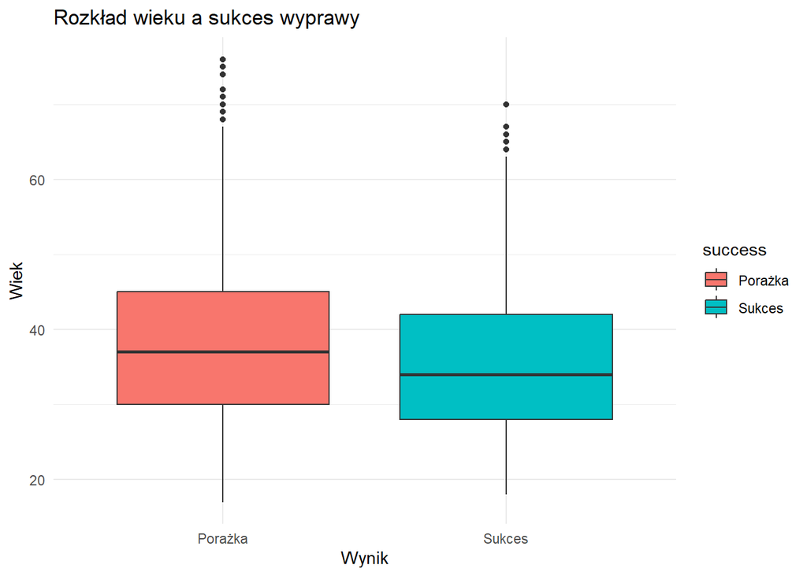

```r
ggplot(dane, aes(x = success, y = age, fill = success)) +
  geom_boxplot() +
  theme_minimal() +
  labs(title = "Rozkład wieku a sukces wyprawy", x = "Wynik", y = "Wiek")
```

# Rozkład wieku

Linia wewnątrz pudełka (Mediana)

Widać, że mediana wieku dla sukcesu jest nieco niższa niż dla porażki. Sugeruje to, że osoby zdobywające szczyt są statystycznie odrobinę młodsze.

Wysokość pudełka (Rozstęp międzykwartylny): Pudełka mają podobną wysokość, co oznacza, że zróżnicowanie wieku w obu grupach jest zbliżone.

Warto również zwrócić uwagę na wartości odstające (na wykresie kropki) – w grupie ‘Porażka’ mamy wspinaczy w wieku blisko 80 lat, co pokazuje, że w podeszłym wieku sukces staje się statystycznie trudniejszy.

### 5. Tlen a sukces - Czy użycie tlenu gwarantuje sukces wejścia?

```r
tlen <- table(dane$oxygen_used, dane$success)
tlen
```

```
##
##             Porażka Sukces
##   Bez tlenu    1165    309
##   Z tlenem      103    498
```

```r
prop.table(tlen, margin = 1) * 100   #opcjonalnie
```

```
##
##              Porażka   Sukces
##   Bez tlenu 79.03664 20.96336
##   Z tlenem  17.13810 82.86190
```

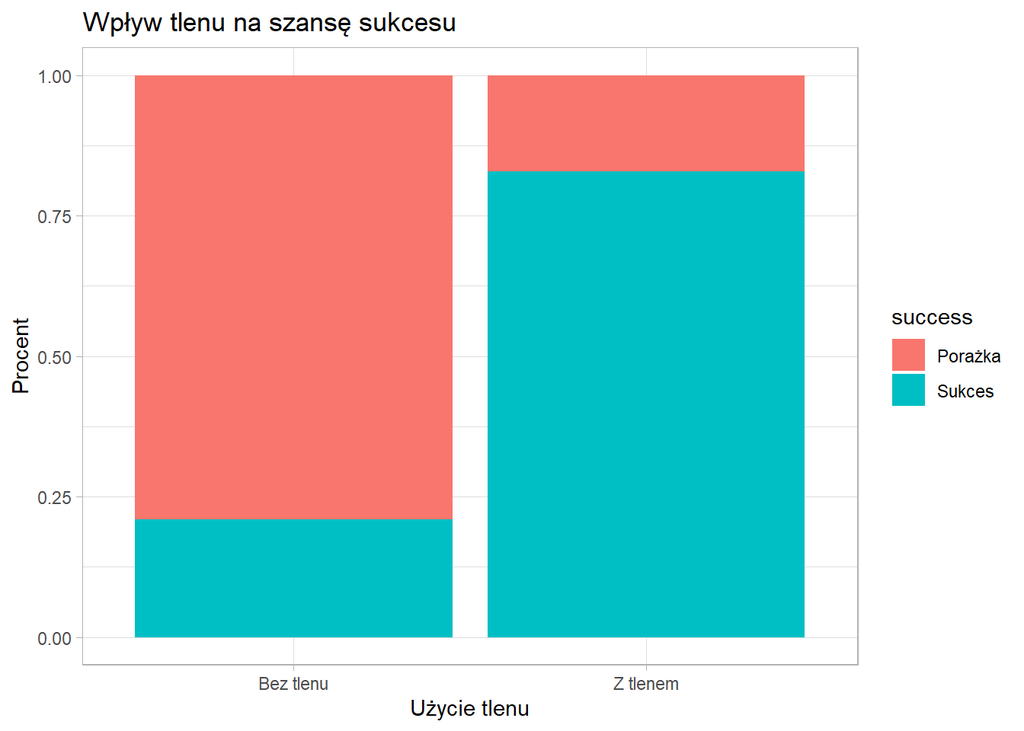

```r
ggplot(dane, aes(x = oxygen_used, fill = success)) +
  geom_bar(position = "fill") +
  theme_light() +
  labs(title = "Wpływ tlenu na szansę sukcesu", x = "Użycie tlenu", y = "Procent")
```

Wykres procentowy wyraźnie pokazuje, że tlen nie jest tylko dodatkiem, ale “game-changerem”. Szansa na sukces bez tlenu jest statystycznie znacznie niższa, co czyni wejścia beztlenowe wyczynem sportowym najwyższej klasy.

### 6. Tlenowy Parasol - Czy osoby używające tlenu rzadziej giną?

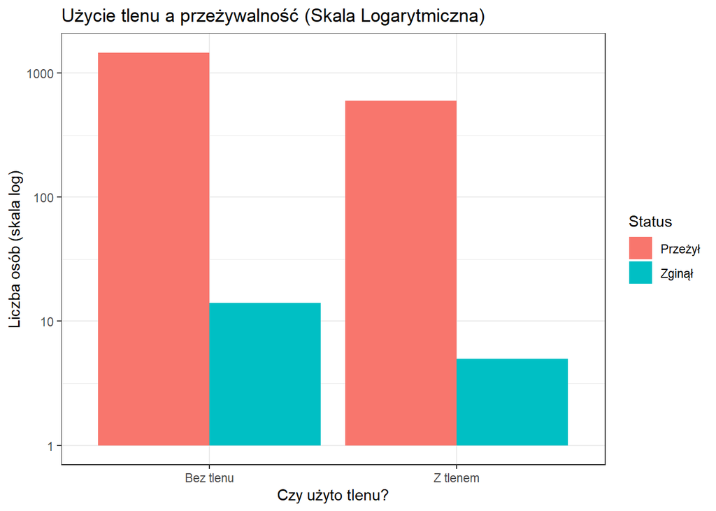

```r
#skala logarytmiczna (przeskalowanie wykresu)

ggplot(dane, aes(x = oxygen_used, fill = died)) +
  geom_bar(position = "dodge") +
  scale_y_log10() +
  theme_bw() +

  labs(title = "Użycie tlenu a przeżywalność (Skala Logarytmiczna)",
       x = "Czy użyto tlenu?",
       y = "Liczba osób (skala log)",
       fill = "Status")
```

Użycie skali logarytmicznej pozwala dostrzec różnice w liczbie zgonów, która jest dość mała w stosunku do całośći uczestników. Widzimy małe liczby zgonów.

### 7. Czy Sherpowie (tj. hired) mają wyższy odsetek sukcesów niż wynajmujący ich klienci?

```r
rola <- table(dane$hired, dane$success)
rola
```

```
##
##             Porażka Sukces
##   Uczestnik    1093    497
##   Sherpa        175    310
```

```r
prop.table(rola, margin = 1) * 100
```

```
##
##              Porażka   Sukces
##   Uczestnik 68.74214 31.25786
##   Sherpa    36.08247 63.91753
```

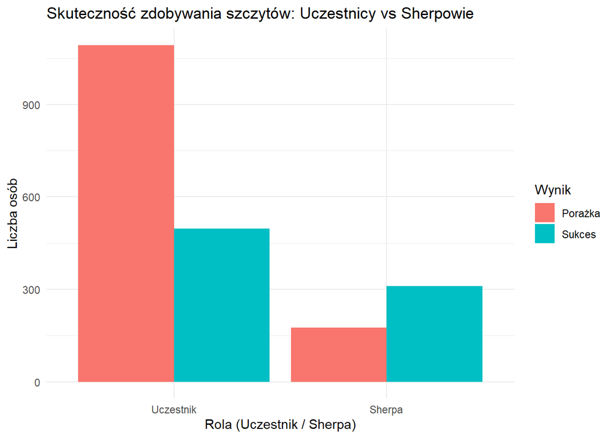

```r
ggplot(dane, aes(x = hired, fill = success)) +
  geom_bar(position = "dodge") +
  theme_minimal() +
  labs(title = "Skuteczność zdobywania szczytów: Uczestnicy vs Sherpowie",
       x = "Rola (Uczestnik / Sherpa)",
       y = "Liczba osób",
       fill = "Wynik")
```

Sherpowie (Hired) wykazują miażdżącą przewagę skuteczności. Dla uczestnika wyprawa to życiowe wyzwanie, a dla Sherpy profesjonalna praca, poparta genetyczną adaptacją do wysokości.

### 8. Co jest najczęstszą przyczyną zgonów? (tylko dla tych, co zginęli)

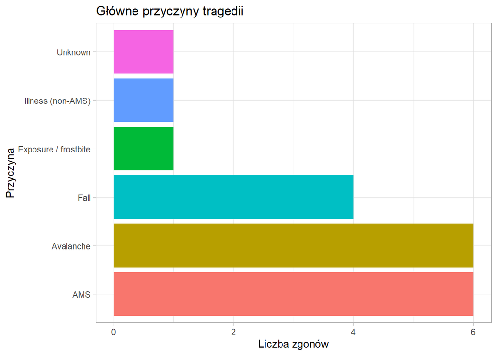

```r
zgony_data <- subset(dane, died == "Zginął")

ggplot(zgony_data, aes(x = reorder(death_cause, death_cause, function(x)-length(x)), fill = death_cause)) +
  geom_bar() +
  coord_flip() +
  theme_light() +
  labs(title = "Główne przyczyny tragedii", x = "Przyczyna", y = "Liczba zgonów") +
  guides(fill = "none")
```

1. Najczęstszymi przyczynami zgonów w badanym zbiorze są AMS (ostra choroba górska) oraz lawiny (Avalanche). Pokazuje to, że wspinacz często przegrywa z fizjologią (przede wszystkim - brak aklimatyzacji) lub nieprzewidywalną naturą, na którą ma ograniczony wpływ.
2. Upadki jako błąd techniczny: Trzecią najczęstszą przyczyną są upadki (Fall). Warto tu zaznaczyć, że często dochodzi do nich w fazie zejścia, gdy organizm jest skrajnie wyczerpany, a koncentracja spada, co czyni powrót ze szczytu statystycznie bardziej niebezpiecznym niż samo podejście.
3. Statystyka „Szczęścia”: Warto wspomnieć, że mimo tragicznego wydźwięku wykresu, ogólna liczba zgonów (łącznie ok. 20 na ponad 2000 uczestników) jest relatywnie niska. Potwierdza to wcześniejszą obserwację z mapy braków z wykresu md.pattern, że większość wspinaczy bezpiecznie kończy wyprawę.

Świetnie wpisuje się w te wyniki znany cytat:

“Szczyt jest tylko połową drogi”

### 9. Gdzie kończą się marzenia? - Rozkład wysokości końcowej dla nieudanych wypraw

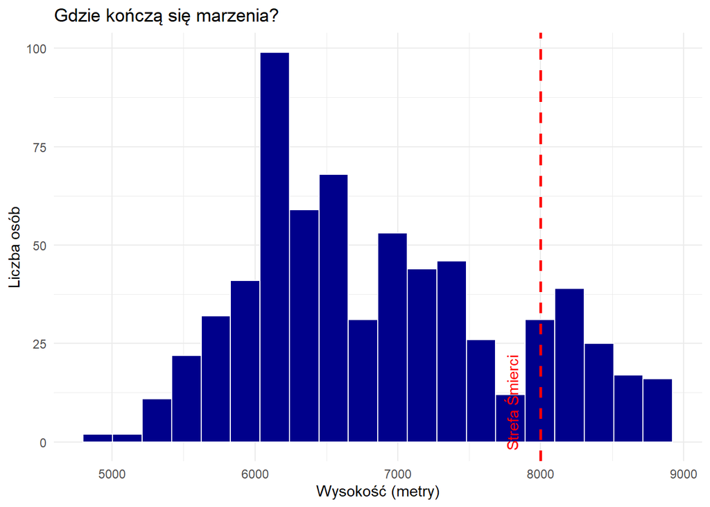

```r
porazki_data <- subset(dane, success == "Porażka")
ggplot(porazki_data, aes(x = highpoint_metres)) +
  geom_histogram(bins = 20, fill = "darkblue", color = "white", na.rm = TRUE) +
  geom_vline(xintercept = 8000, color = "red", linetype = "dashed", size = 1) +
  annotate("text", x = 7800, y = 10, label = "Strefa Śmierci", color = "red", angle = 90) +
  theme_minimal() +
  labs(title = "Gdzie kończą się marzenia?", x = "Wysokość (metry)", y = "Liczba osób")
```

Ostatni sprawdzian – Obóz IV (Przełęcz Południowa dot. Everestu, ok. 7900–8000 m) Jest to już “Strefa Śmierci”. To stąd rusza się na atak szczytowy. Osoby, które zawróciły na tej wysokości, często padły ofiarą pogody lub wyczerpania zasobów tlenu w butlach.